# Nobel Prize winners

Rika Gorn

For this Tidy Tuesday, let’s look at Nobel Prize winners from 1901 to 2016 and see if we can find some fun trends. I’m going to go ahead and guess that a majority of winners are males from the U.S. or Europe. The first female winner was Marie Curie, I believe, but I could be wrong!

First we setup our libraries:

```r
library(tidyverse)
library(janitor)
library(scales)
library(readr)
library(lubridate)
library(ggbeeswarm)
library(ggridges)
library(maps)
```

Let’s import the data for [Tidy Tuesday](https://github.com/rfordatascience/tidytuesday) which comes to us from [Kaggle](https://www.kaggle.com/nobelfoundation/nobel-laureates).

```r
nobel <- read_csv("https://raw.githubusercontent.com/rfordatascience/tidytuesday/master/data/2019/2019-05-14/nobel_winners.csv")
```

Now lets take a quick look at our variables with `glimpse`. They are all primarily characters and integers which makes sense.

```r
glimpse(nobel)
```

```
## Observations: 969
## Variables: 18
## $ prize_year           <int> 1901, 1901, 1901, 1901, 1901, 1901, 1902,...
## $ category             <chr> "Chemistry", "Literature", "Medicine", "P...
## $ prize                <chr> "The Nobel Prize in Chemistry 1901", "The...
## $ motivation           <chr> "\"in recognition of the extraordinary se...
## $ prize_share          <chr> "1/1", "1/1", "1/1", "1/2", "1/2", "1/1",...
## $ laureate_id          <int> 160, 569, 293, 462, 463, 1, 161, 571, 294...
## $ laureate_type        <chr> "Individual", "Individual", "Individual",...
## $ full_name            <chr> "Jacobus Henricus van 't Hoff", "Sully Pr...
## $ birth_date           <date> 1852-08-30, 1839-03-16, 1854-03-15, 1828...
## $ birth_city           <chr> "Rotterdam", "Paris", "Hansdorf (Lawice)"...
## $ birth_country        <chr> "Netherlands", "France", "Prussia (Poland...
## $ gender               <chr> "Male", "Male", "Male", "Male", "Male", "...
## $ organization_name    <chr> "Berlin University", NA, "Marburg Univers...
## $ organization_city    <chr> "Berlin", NA, "Marburg", NA, NA, "Munich"...
## $ organization_country <chr> "Germany", NA, "Germany", NA, NA, "German...
## $ death_date           <date> 1911-03-01, 1907-09-07, 1917-03-31, 1910...
## $ death_city           <chr> "Berlin", "Châtenay", "Marburg", "Heiden"...
## $ death_country        <chr> "Germany", "France", "Germany", "Switzerl...
```

First, let’s look at how men and women compare in different categories. Medicine has received the most winners across all the categories, and women have the most winners in the Peace, Literature, and Medicine categories.

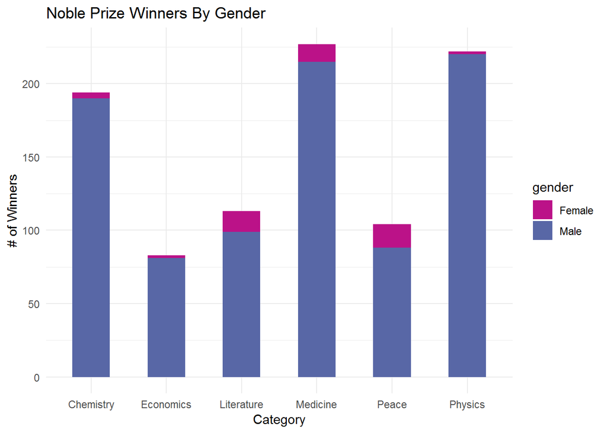

```r
nobel %>%
  mutate(age =  prize_year - year(birth_date)) %>%
  filter(!is.na(gender)) %>%
  ggplot(aes(x = category,
             fill = gender)) +
  geom_bar(width = 0.5)+
  theme_minimal()+
  scale_fill_manual(values=c("#BB1288", "#5867A6", "gray"))+
  labs(title = "Noble Prize Winners By Gender",
       colour = "Gender",
       x = "Category",
       y = "# of Winners")
```

```r
nobel %>%
  filter(gender == "Female") %>%
  select(full_name, prize_year, category) %>%
  group_by(category) %>%
  count() %>%
  arrange(desc(n))
```

```
## # A tibble: 6 x 2
## # Groups:   category [6]
##   category       n
##   <chr>      <int>
## 1 Peace         16
## 2 Literature    14
## 3 Medicine      12
## 4 Chemistry      4
## 5 Economics      2
## 6 Physics        2
```

```r
nobel %>%
  filter(gender == "Female") %>%
  select(full_name, prize_year, category) %>% head()
```

```
## # A tibble: 6 x 3
##   full_name                                           prize_year category
##   <chr>                                                    <int> <chr>
## 1 Marie Curie, née Sklodowska                               1903 Physics
## 2 Baroness Bertha Sophie Felicita von Suttner, née C~       1905 Peace
## 3 Selma Ottilia Lovisa Lagerlöf                             1909 Literatu~
## 4 Marie Curie, née Sklodowska                               1911 Chemistry
## 5 Grazia Deledda                                            1926 Literatu~
## 6 Sigrid Undset                                             1928 Literatu~
```

So in the last 115 years we’ve had 50 female nobel price laureates. And I was right! The first winner was Marie Curie!

There were a few NA’s that I filtered out for gender in the above chart that I’d like to check out.

```r
nobel %>% filter(is.na(gender)) %>% select(full_name, category)
```

```
## # A tibble: 26 x 2
##    full_name                                                      category
##    <chr>                                                          <chr>
##  1 Institut de droit international (Institute of International L~ Peace
##  2 Bureau international permanent de la Paix (Permanent Internat~ Peace
##  3 Comité international de la Croix Rouge (International Committ~ Peace
##  4 Office international Nansen pour les Réfugiés (Nansen Interna~ Peace
##  5 Comité international de la Croix Rouge (International Committ~ Peace
##  6 Friends Service Council (The Quakers)                          Peace
##  7 American Friends Service Committee (The Quakers)               Peace
##  8 Office of the United Nations High Commissioner for Refugees (~ Peace
##  9 Comité international de la Croix Rouge (International Committ~ Peace
## 10 Ligue des Sociétés de la Croix-Rouge (League of Red Cross Soc~ Peace
## # ... with 16 more rows
```

Fascinating, there were 26 organizations rather than individuals that won the Nobel Peace Prize.

A fellow TidyTuesdayer [Othomenantegazza](https://twitter.com/othomn/status/1128426237834276865) had a really awesome way of showing similar information with a beeswarm graph that I wanted to recreate here. They also changed the alpha in their chart which changes the translucency of the dots, but I left that alone here. I also wanted to try out the `ggridges` package so I made a similar graph looking at age and gender across categories.

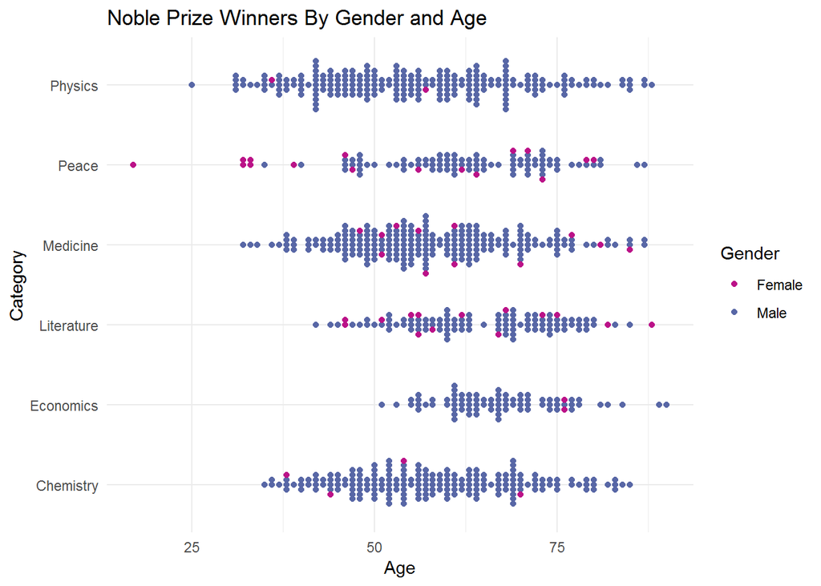

```r
nobel %>%
  mutate(age =  prize_year - year(birth_date)) %>%
  ggplot(aes(x = category,
             y = age,
             colour = gender)) +
  ggbeeswarm::geom_beeswarm() +
  coord_flip() +
  scale_color_manual(values = c("#BB1288", "#5867A6")) +
  theme_minimal() +
  labs(title = "Noble Prize Winners By Gender and Age",
       colour = "Gender",
       x = "Category",
       y = "Age")
```

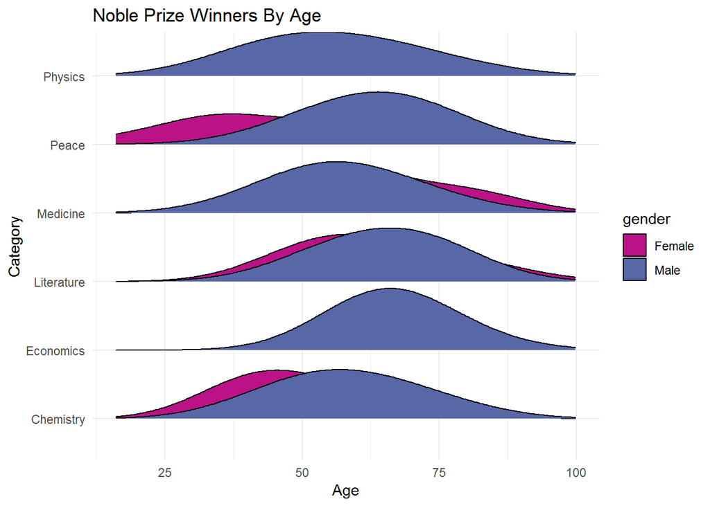

```r
nobel %>%
  mutate(age =  prize_year - year(birth_date)) %>%
  ggplot(aes(x = age,
             y = category,
            fill = gender)) +
  geom_density_ridges(scale = 0.9) +
  scale_x_continuous(limits = c(16, 100))+
   scale_fill_manual(values = c("#BB1288", "#5867A6")) +
  theme_minimal() +
  labs(title = "Noble Prize Winners By Age",
       colour = "Gender",
       x = "Age",
       y = "Category")
```

I want to make a heat map but for this will need to bring in longitude and latitude data and also clean up our countries since many of them no longer exist. In general, I want our birth_country variable to conform to the region available in the `maps` package.

```r
map.world <- map_data('world')
map_countries <- distinct(map.world, region)
```

Now let’s filter the original dataset to only include birth_countries that have more than 5 winners and is not missing. This cuts our dataset down from 969 to 792 winners and top 24 countries. Then we can take a look at some of our birth_country mismatches which we will need to recode.

```r
nobel_countries <- nobel %>% group_by(birth_country) %>% count() %>% filter(n >5, !is.na(birth_country)) %>% arrange(desc(n))

anti_join(nobel_countries, map.world, by = c('birth_country' = 'region')) %>% select(birth_country) %>% group_by(birth_country) %>% count(sort = T)
```

```
## # A tibble: 6 x 2
## # Groups:   birth_country [6]
##   birth_country                n
##   <chr>                    <int>
## 1 Germany (Poland)             1
## 2 Prussia (Germany)            1
## 3 Prussia (Poland)             1
## 4 Scotland                     1
## 5 United Kingdom               1
## 6 United States of America     1
```

And let’s fix those mismatches by recoding them to the names that are in our map.world dataset.

```r
nobel <- nobel %>% mutate(birth_country = recode(birth_country,
                                                 "United States of America" = "USA",
                                                 "United Kingdom" = "UK",
                                                 "Scotland" = "UK",
                                                 "Northern Ireland" = "Ireland",
                                                 "Germany (Poland)" = "Poland",
                                                 "Prussia (Germany)" = "Germany",
                                                 "Prussia (Poland)" = "Poland"
                                                  )
                            )
```

```r
country_list <- nobel_countries$birth_country

nobel_small <- nobel %>% filter(birth_country %in% country_list)
```

Let’s make sure Now let’s make our map dataset by combining the nobel dataset and the map dataset.

```r
nobel_small <- left_join(nobel_small, nobel_countries, by ="birth_country") %>% rename("num_winners" = "n") #this add the count of winners

nobel_map <- left_join( map.world, nobel_small, by = c("region"= "birth_country"))
```

[figure not shown]

```r
ggplot(nobel_map, aes( x = long, y = lat, group = group)) +
  geom_polygon(aes(fill = num_winners))+
  scale_fill_gradientn(colours = c('#461863','#404E88','#2A8A8C','#7FD157','#F9E53F')
                       ,values = scales::rescale(c(5, 50, 100, 200, 300))
                       ,labels = comma
                       ,breaks = c(5, 50, 100, 200, 300)
  ) +
  labs(fill = '# of Nobel Winners'
              ,title = 'U.S. and Europe Win Most Nobel Prizes'
       ,x = NULL
       ,y = NULL) +
  theme(text = element_text(family = 'Gill Sans', color = '#EEEEEE')
        ,plot.title = element_text(size = 20)
        ,plot.subtitle = element_text(size = 14)
        ,axis.ticks = element_blank()
        ,axis.text = element_blank()
        ,panel.grid = element_blank()
        ,panel.background = element_rect(fill = '#333333')
        ,plot.background = element_rect(fill = '#333333')
        ,legend.position = c(.18,.36)
        ,legend.background = element_blank()
        ,legend.key = element_blank()
  ) +
  annotate(geom = 'text'
           ,label = 'Source: Kaggle | Plot by @RikaGorn '
           ,x = 18, y = -55
           ,size = 3
           ,family = 'Gill Sans'
           ,color = '#CCCCCC'
           ,hjust = 'left'
  )
```